# Flagging Inland Data - Explore Grossrange

## Summary

CMAR has collected data on several inland bodies of freshwater in Nova Scotia through the wild Atlantic salmon river monitoring project. In addition, CMAR has data collected on several freshwater lakes (e.g. Piper Lake), which is currently published through the Water Quality branch of the [Coastal Monitoring Program](https://cmar.ca/coastal-monitoring-program/#station).

CMAR intends to process and republish all inland data under a new “Inland” branch of the Coastal Monitoring Program. Data will be processed in a similar manner to the water quality data, and data flags will be applied using the qaqcmar package.

It is suspected that sensors on some rivers were out of the water for some period of time during the deployment. Data flagging efforts will flag data for periods of time sensors were suspected to be exposed. During the periods in which sensors were exposed to air, recorded temperatures fluctuate more quickly than when sensors are submerged.

The purpose of this document is to help CMAR determine appropriate data flagging tests and thresholds for freshwater (inland) data. We do not currently have enough freshwater data to conduct as thorough an analysis as was done on the saltwater water quality data to develop tests and thresholds, so thresholds may be picked in more subjective ways.

##### Waterbodies in dataset:

```
[1] "Gold River"         "LaHave River"       "Liscomb River"
[4] "Mersey River"       "Musquodoboit River" "Roseway River"
[7] "Round Hill River"   "Salmon River"       "Tusket River"
```

##### Stations in dataset:

```
 [1] "Gold 2"         "LaHave 1"       "LaHave 2"       "LaHave 3"
 [5] "Liscomb 1"      "Liscomb 2"      "Mersey 2"       "Musquodoboit 1"
 [9] "Musquodoboit 2" "Musquodoboit 3" "Roseway 1"      "Roseway 2"
[13] "Round Hill 1"   "Round Hill 2"   "Round Hill 3"   "Salmon 1"
[17] "Salmon 2"       "Tusket 1"       "Tusket 2"       "Tusket 3"
```

##### Stations which may have experienced air exposure:

- Liscomb 1
- Liscomb 2
- LaHave 2
- Mersey 2
- Tusket 3
- Possibly Musquodoboit 1 and 2

# Station Locations

Approximate location of stations included in analysis.

[interactive chart not shown]

## Plot all Station Data

**Gold 2**

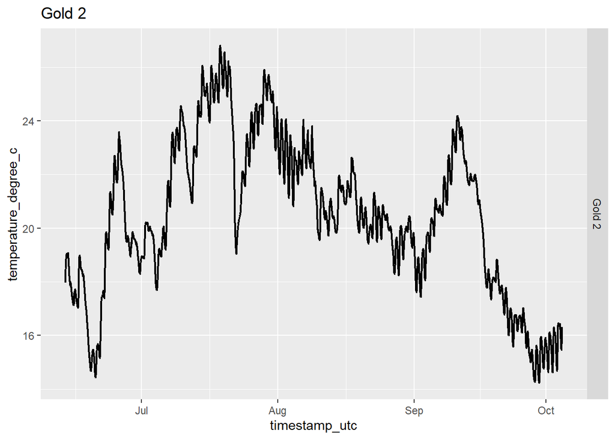

**LaHave 1**

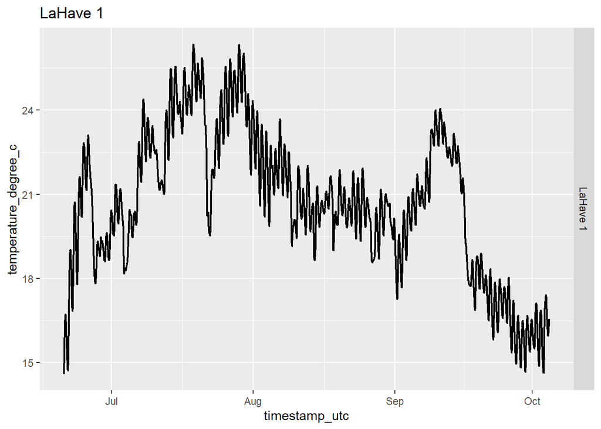

**LaHave 2**

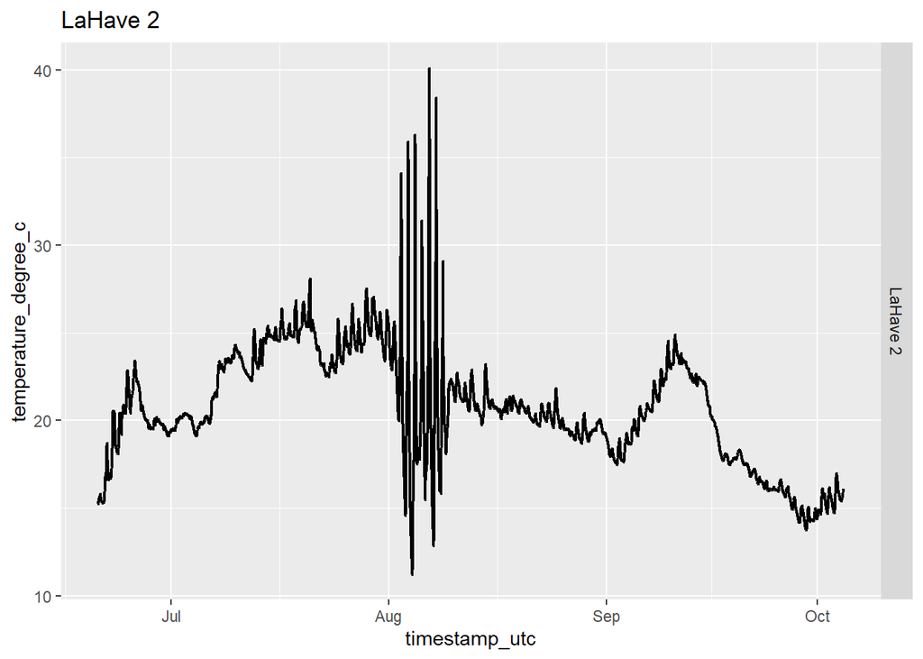

**LaHave 3**

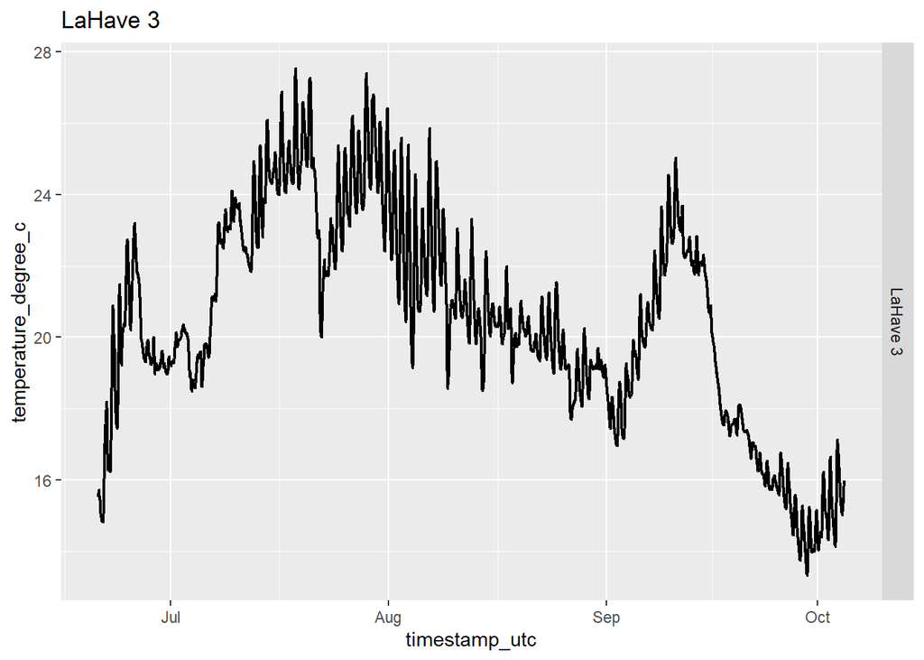

**Liscomb 1**

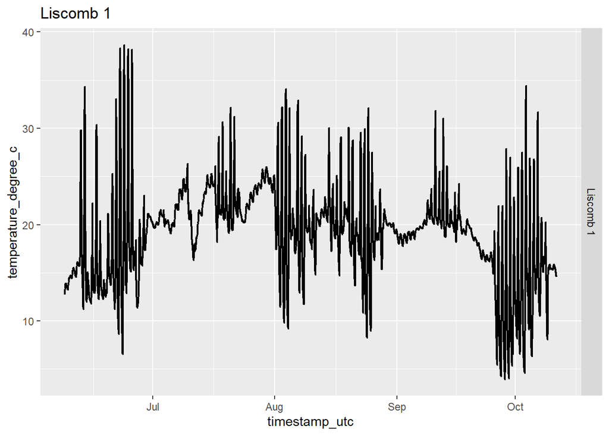

**Liscomb 2**

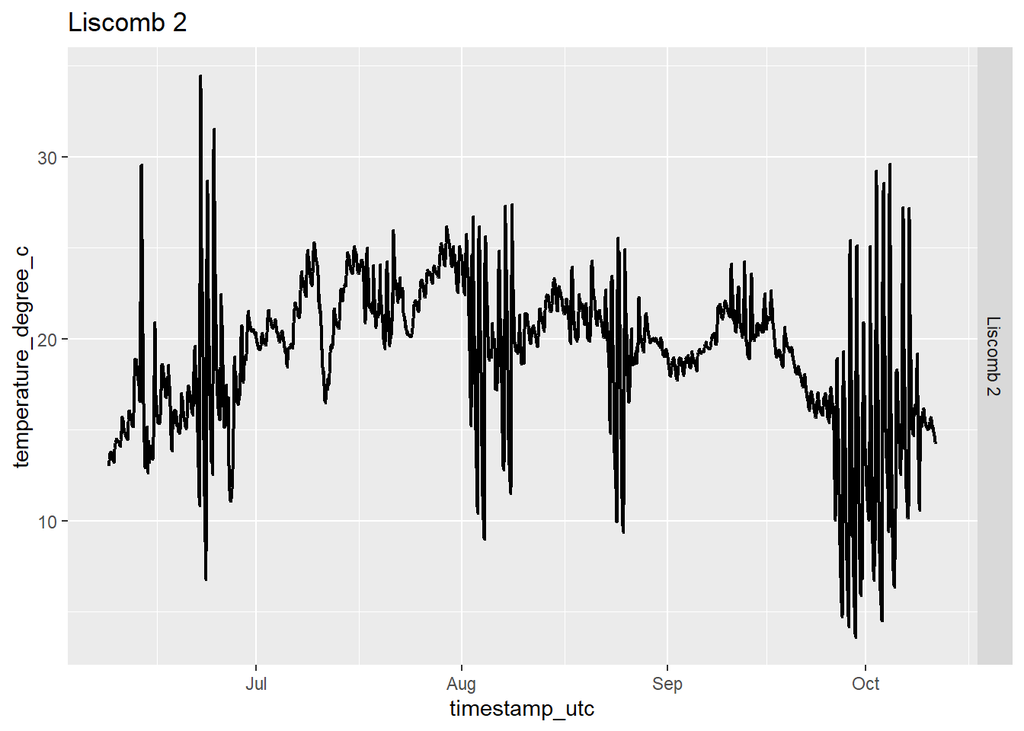

**Mersey 2**

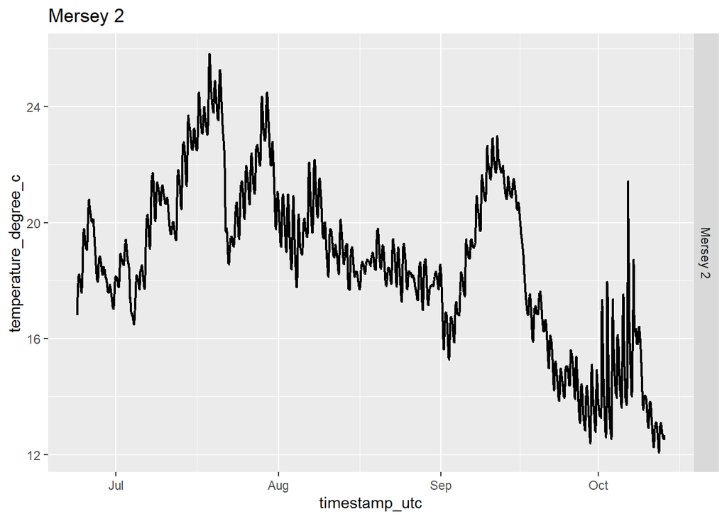

**Musquodoboit 1**

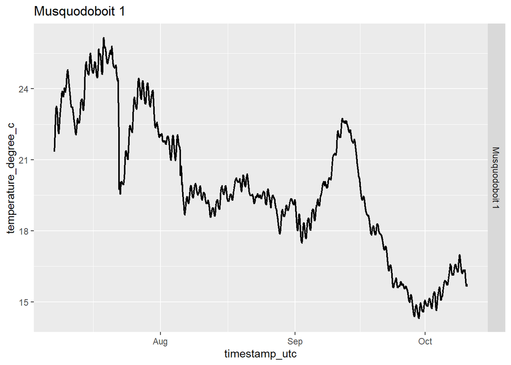

**Musquodoboit 2**

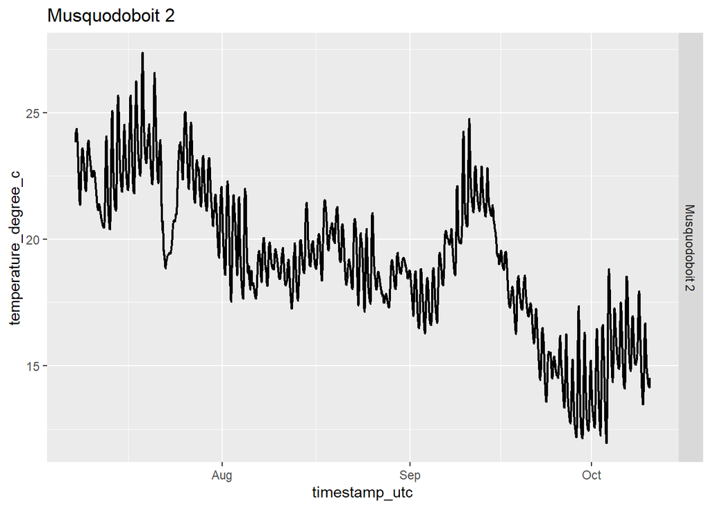

**Musquodoboit 3**

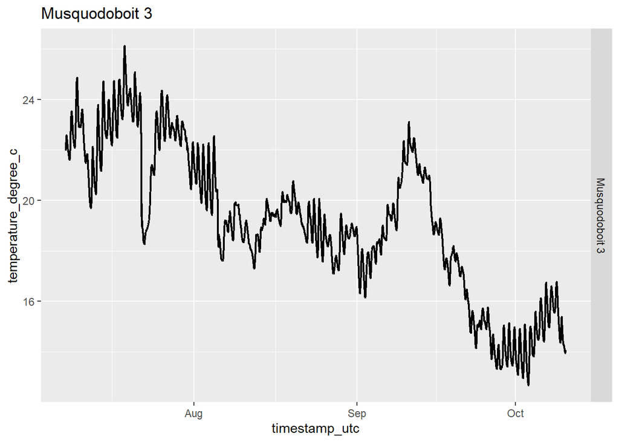

**Roseway 1**

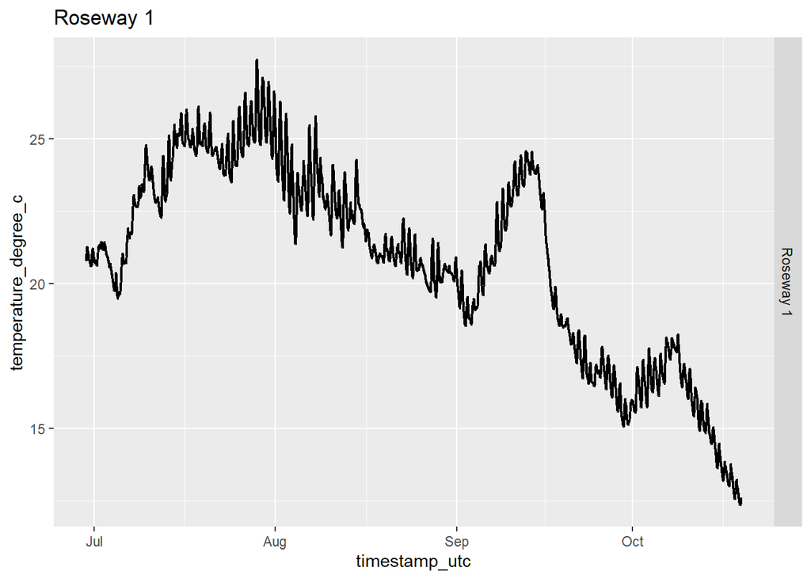

**Roseway 2**

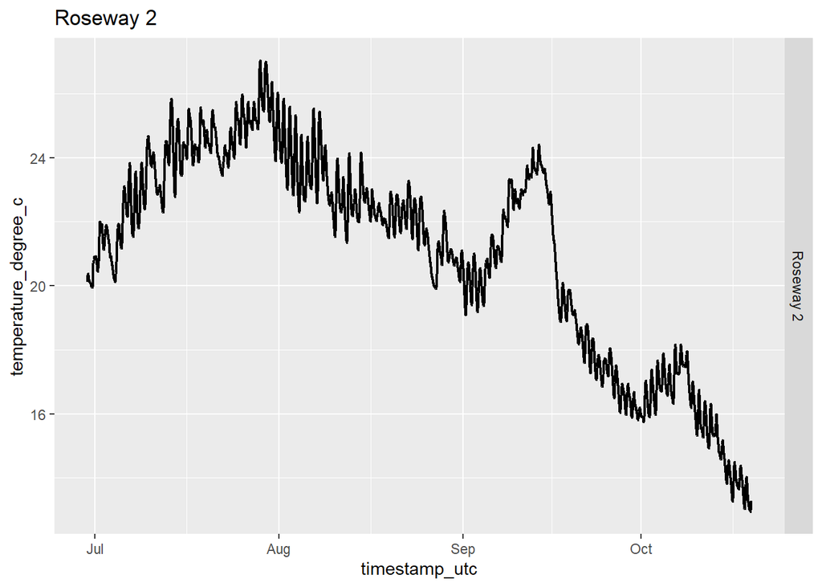

**Round Hill 1**

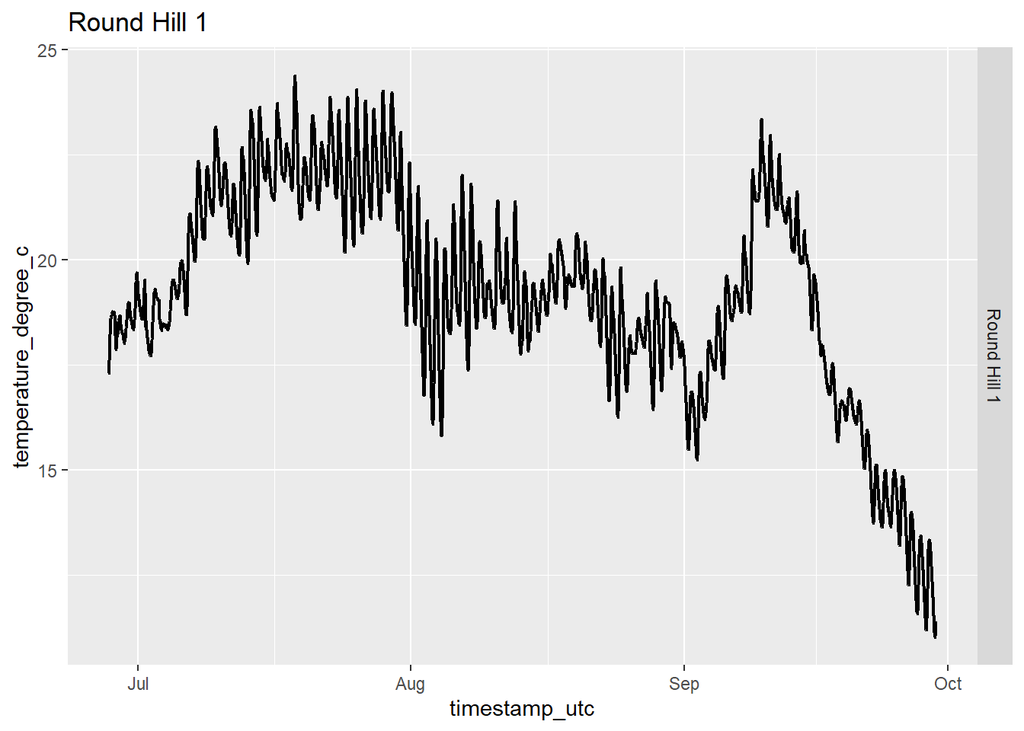

**Round Hill 2**

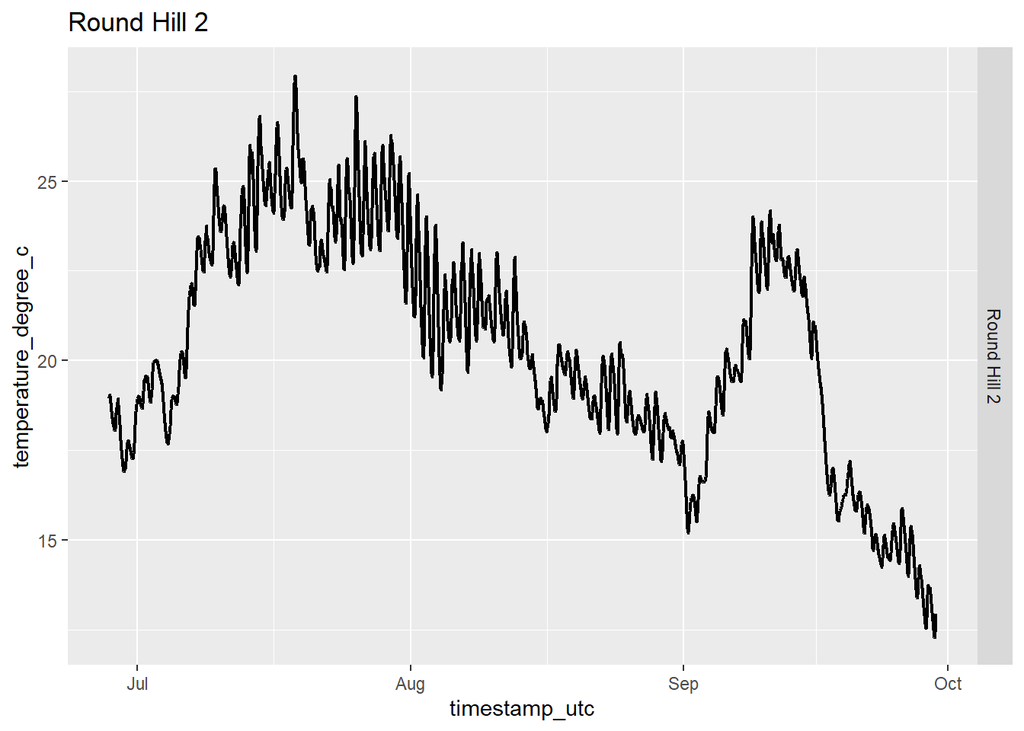

**Round Hill 3**

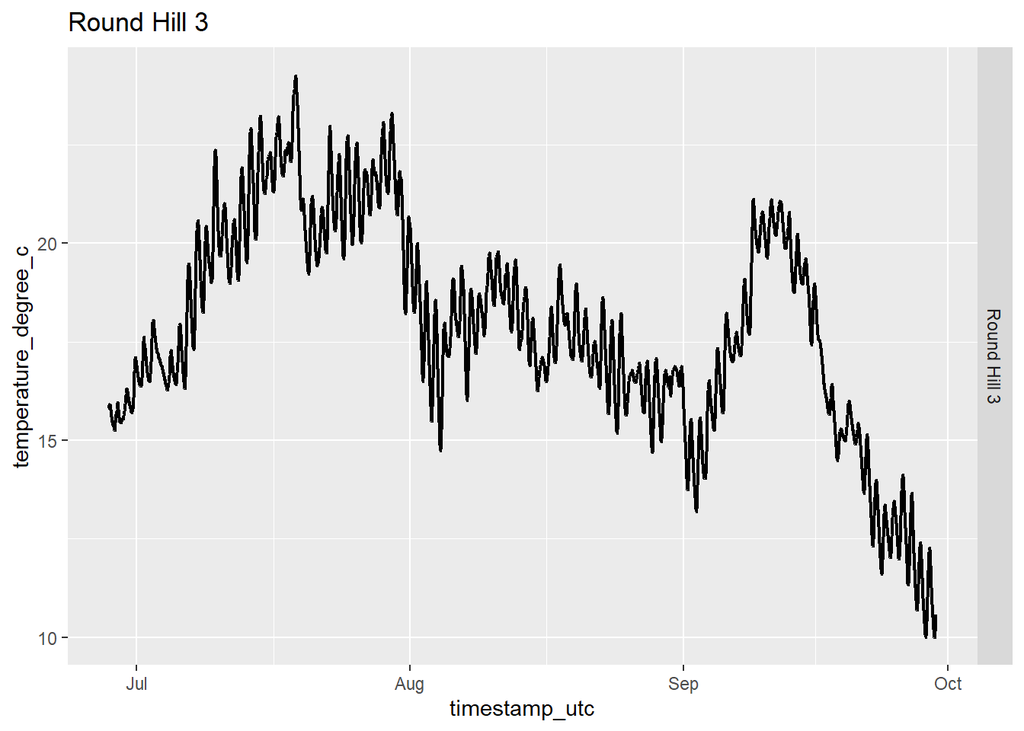

**Salmon 1**

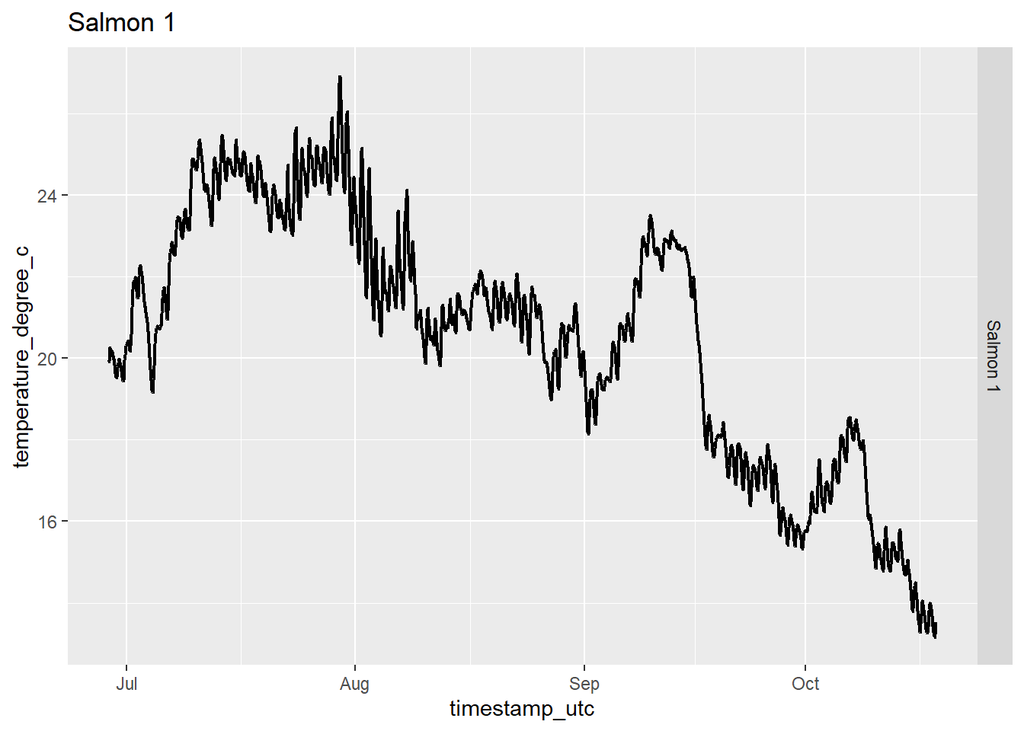

**Salmon 2**

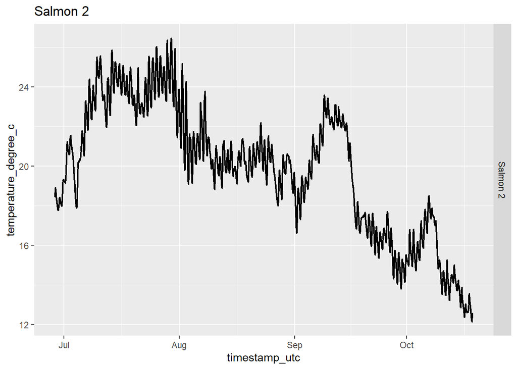

**Tusket 1**

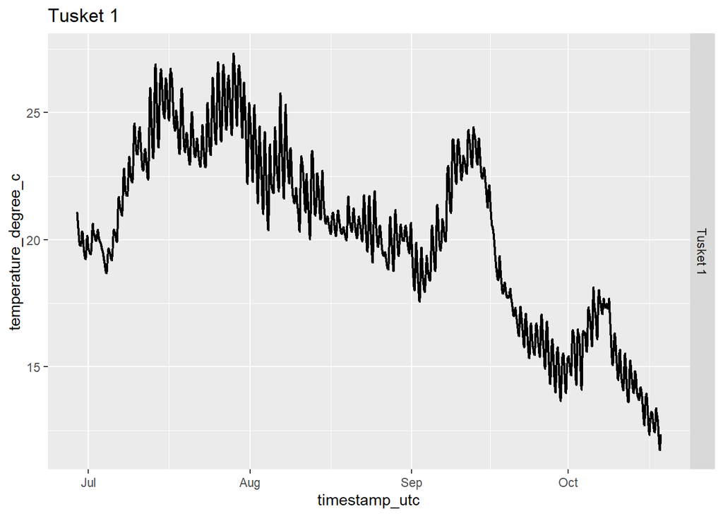

**Tusket 2**

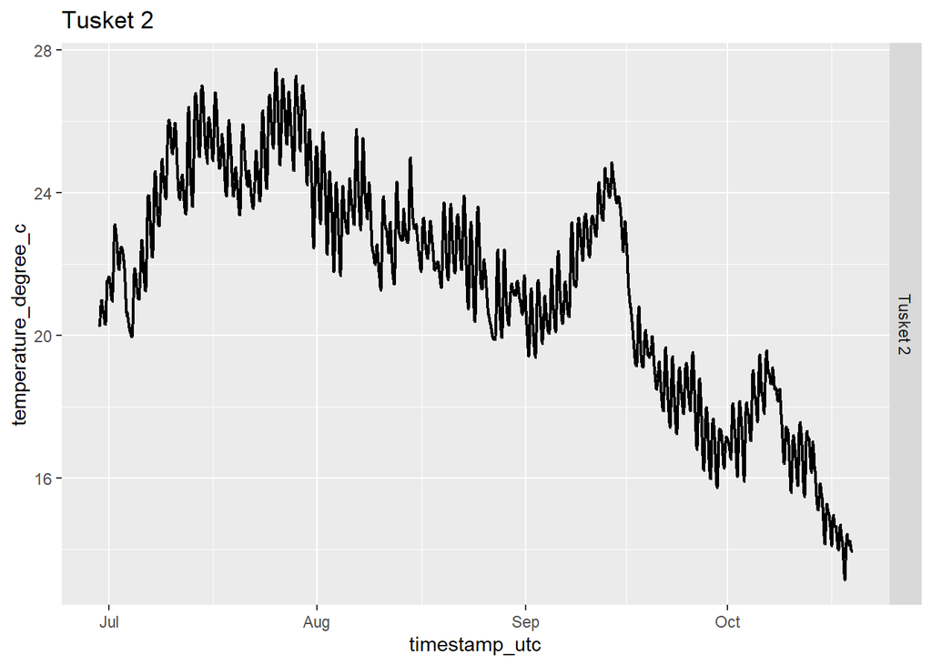

**Tusket 3**

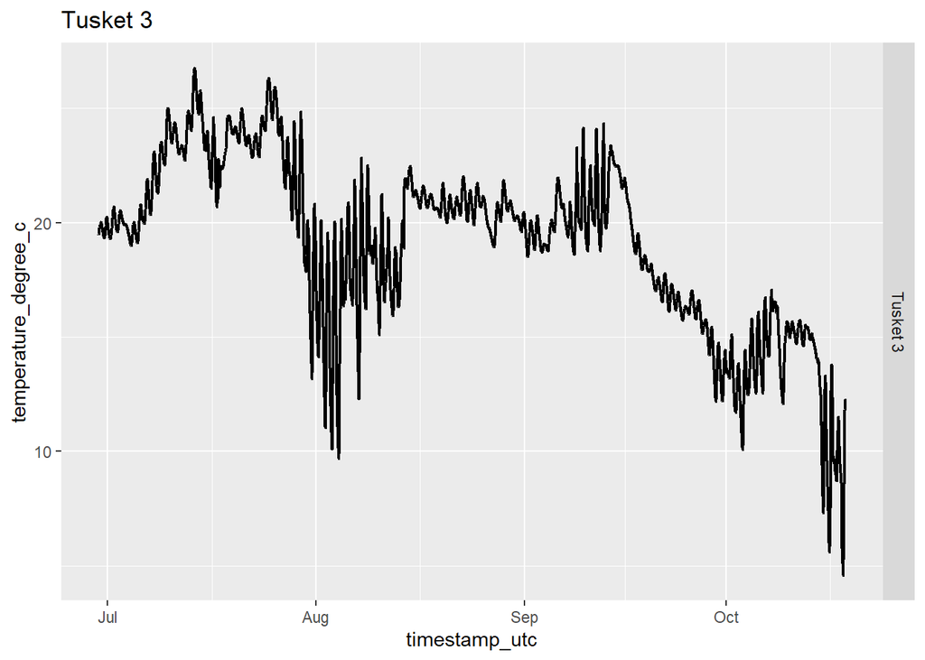

## Plot Cleaned Station Data

Suspected outliers have been removed from the following datasets:

- Liscomb 1
- Liscomb 2
- LaHave 2
- Mersey 2
- Tusket 3

**Gold 2**

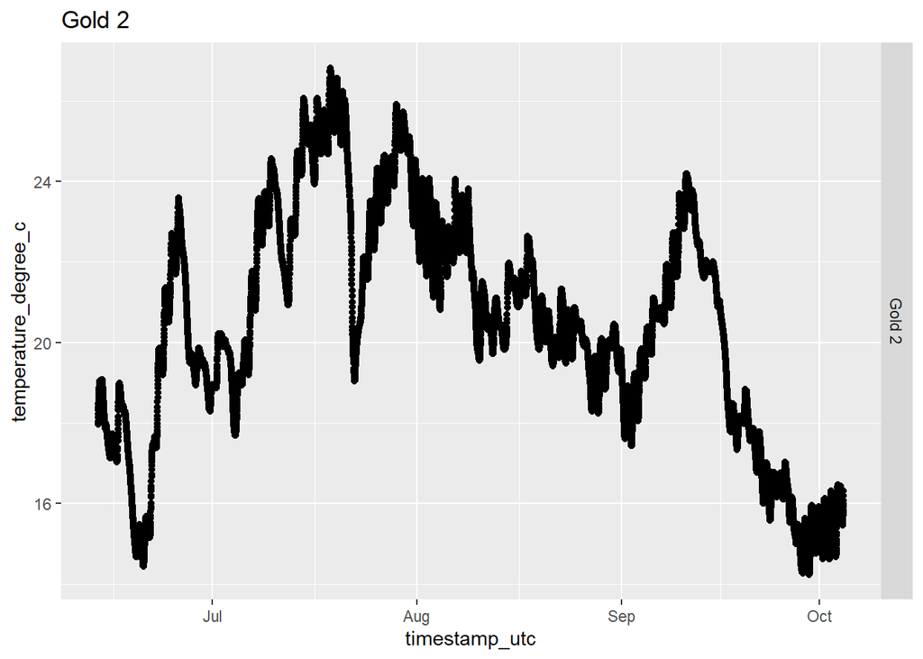

**LaHave 1**

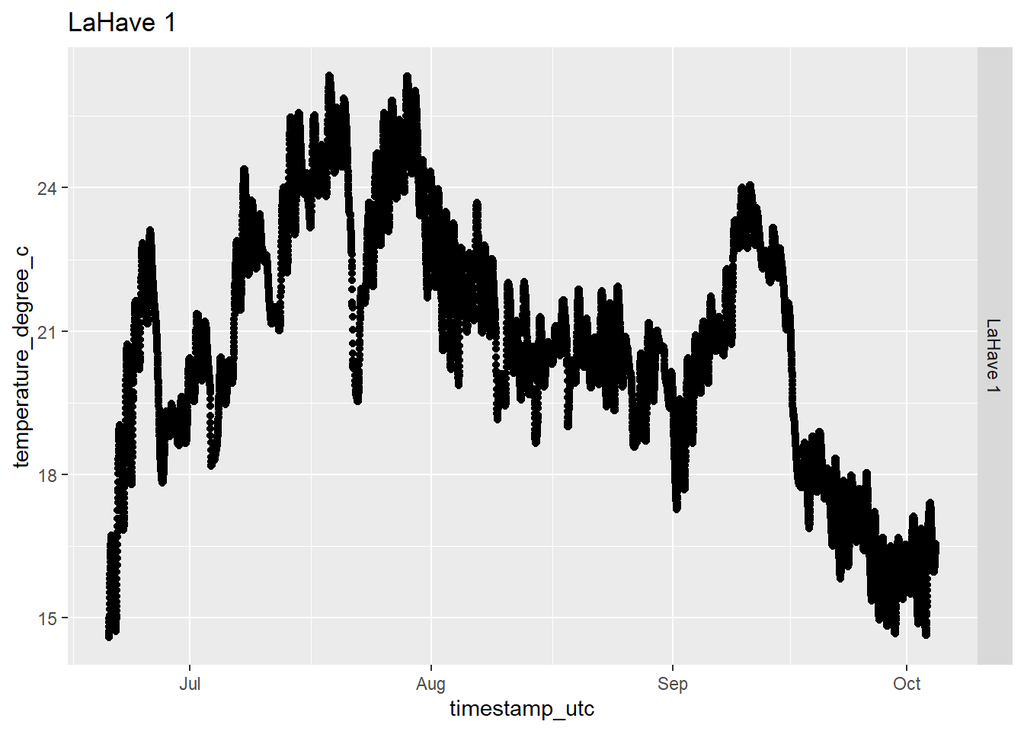

**LaHave 3**

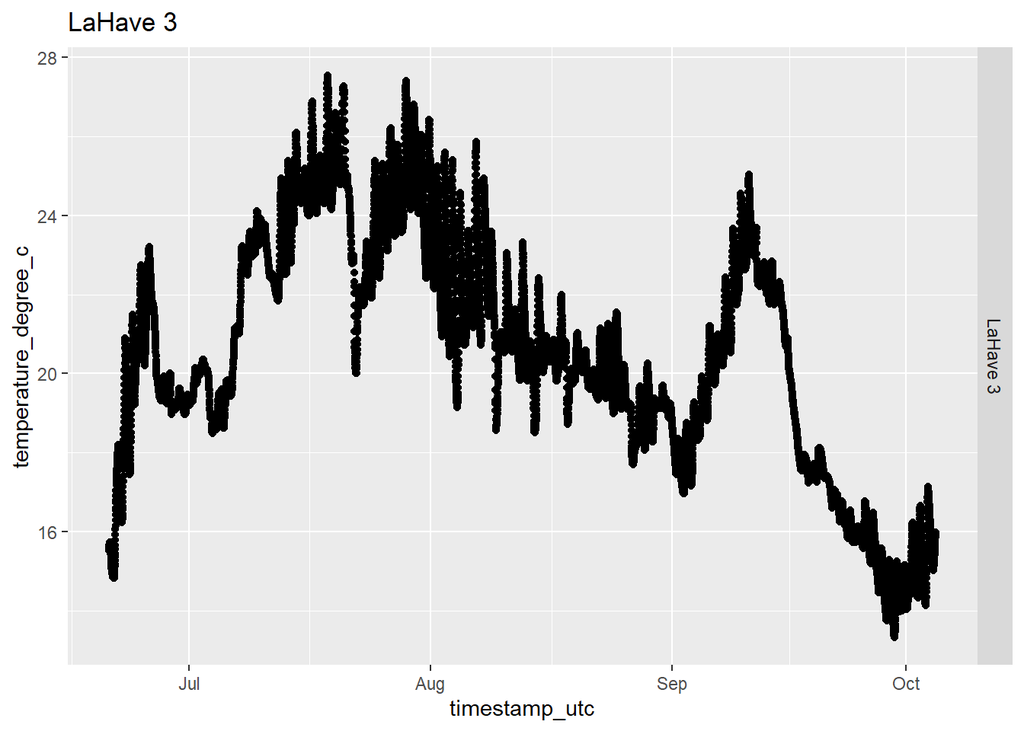

**Musquodoboit 1**

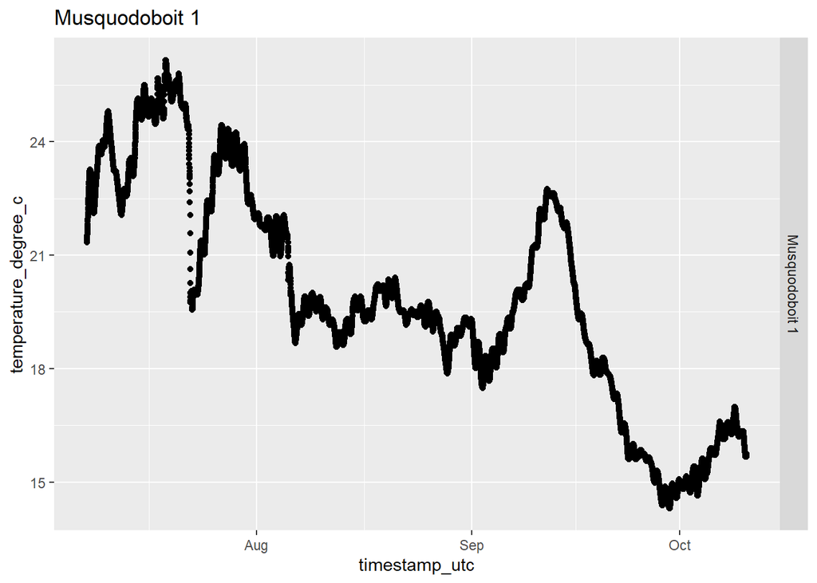

**Musquodoboit 2**

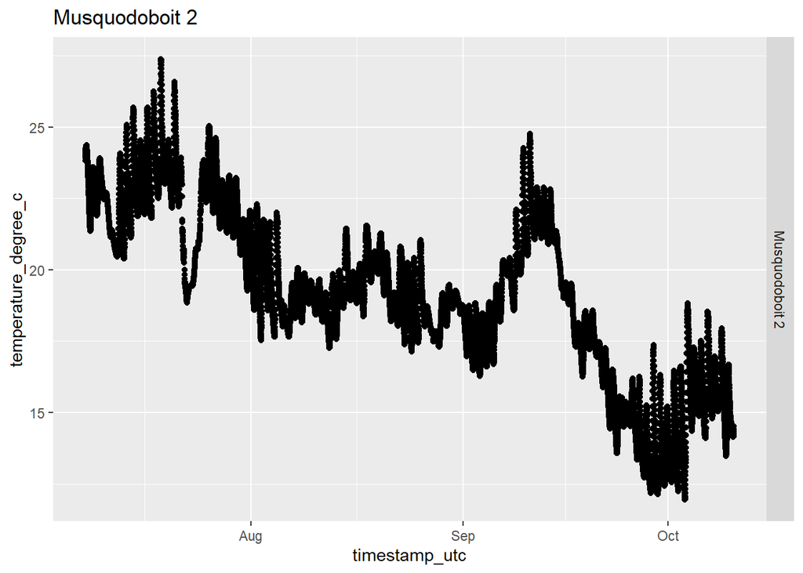

**Musquodoboit 3**

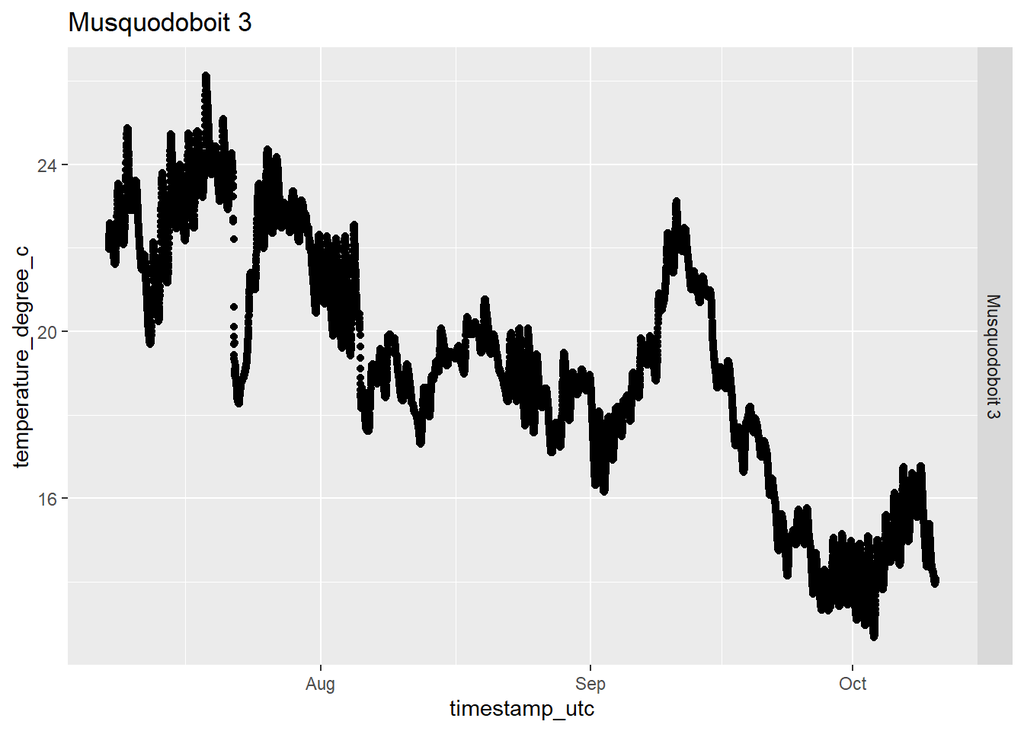

**Roseway 1**

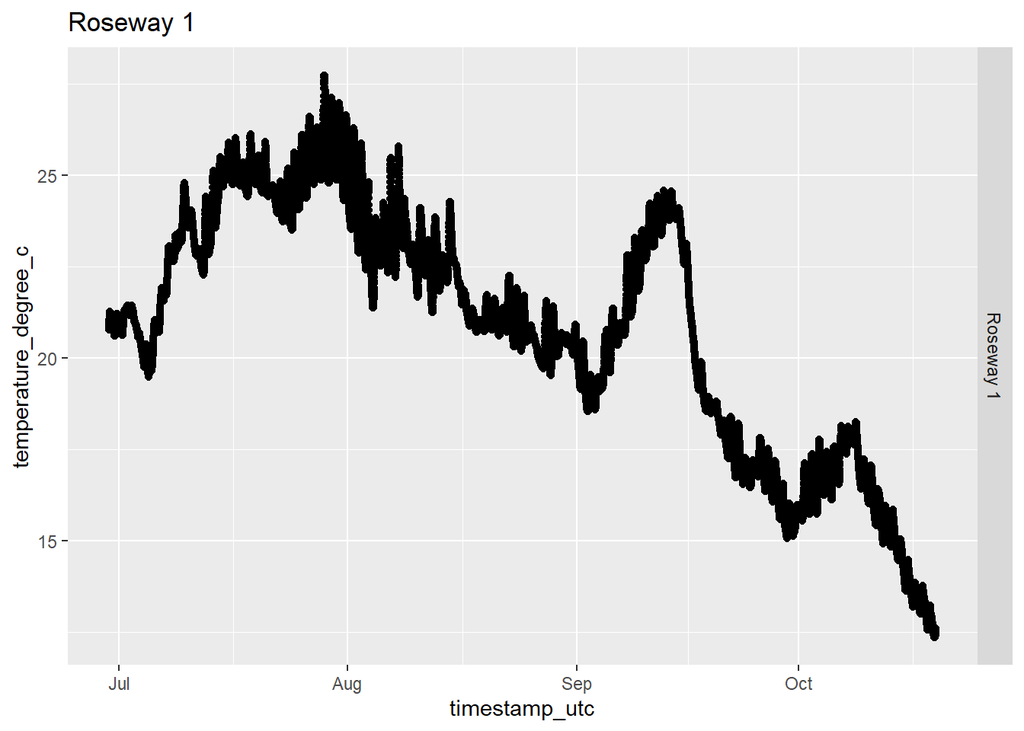

**Roseway 2**

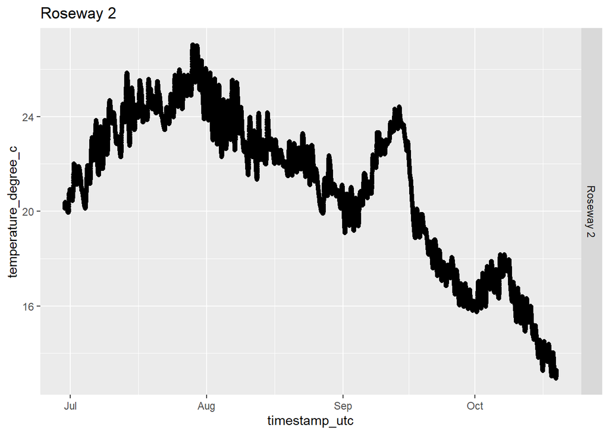

**Round Hill 1**

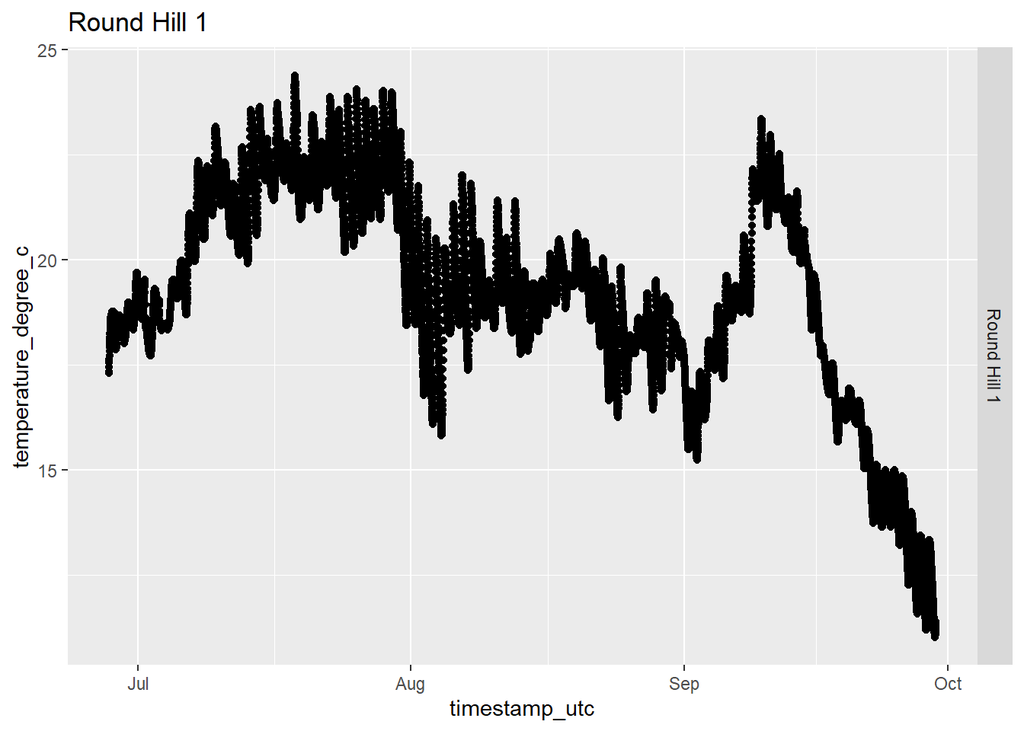

**Round Hill 2**

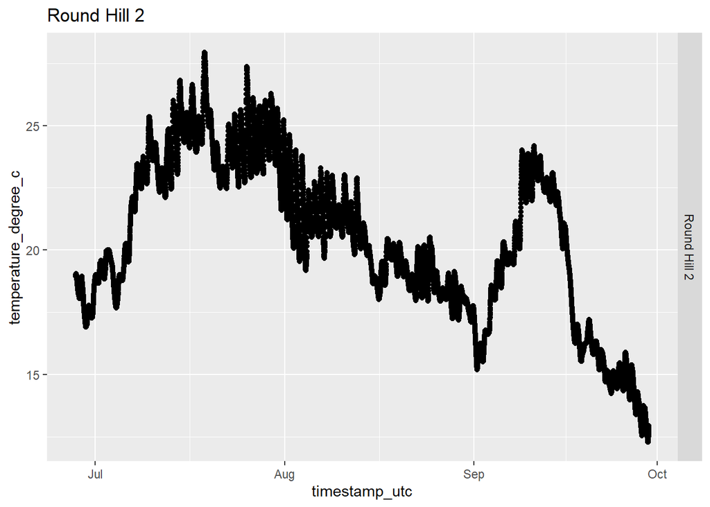

**Round Hill 3**

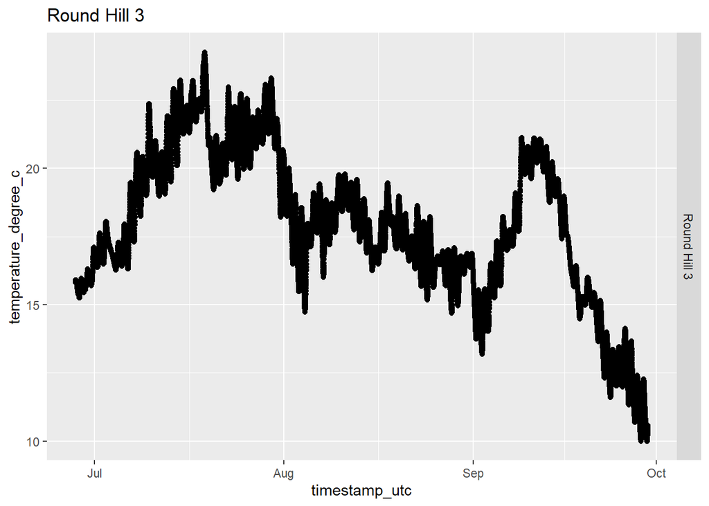

**Salmon 1**

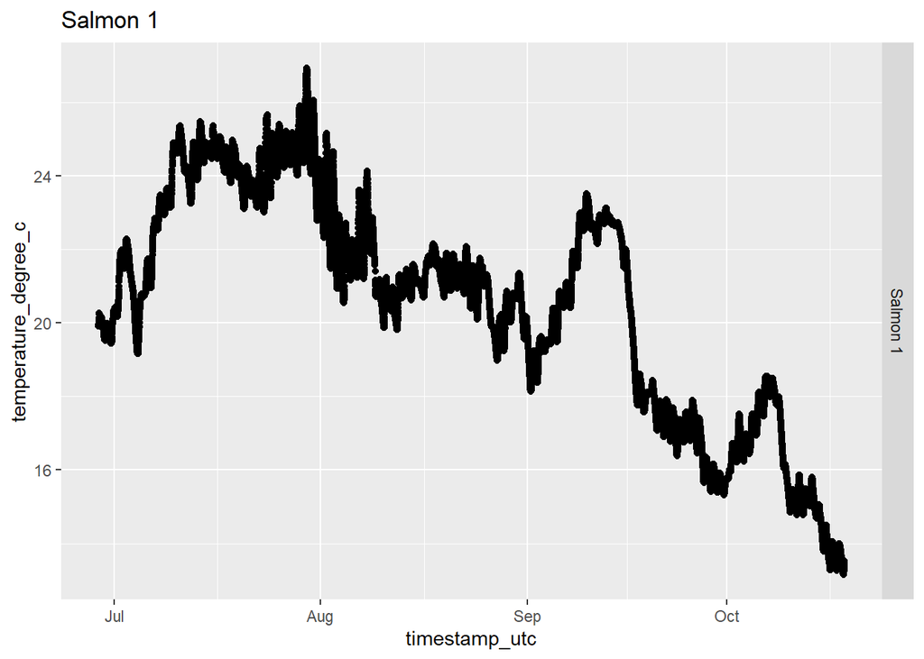